# Week 13 HW

Author

Kent Glover

## Introduction

For this assignment, I need to process temperature and light data from four tide pools. The goal is to calculate summary statistics (mean and standard deviation) for each pool using two different methods: a standard `for loop` and a `purrr::map` function.

The main challenge is that the `Intensity.lux` column contains commas which R reads as characters. I have to clean this before calculating means or the code will error out.

```r
#load libraries
library(tidyverse)
library(here)
library(knitr)

#set path to data
data_dir <- here("Week_13", "Data", "homework")

#get list of csv files
files <- list.files(data_dir, pattern = "\\.csv$", full.names = TRUE)
```

## Data Processing with a For Loop

This approach explicitly iterates through each file path in our list. Inside the loop, the code reads the CSV, cleans the Intensity.lux and Temp.C columns by converting them to numeric types, and then calculates the mean and standard deviation for both temperature and light intensity. These individual dataframes are stored in a list and then combined into a final summary table using bind_rows().

```r
#empty list to store results
results_list <- vector("list", length(files))

#start the loop
for (i in seq_along(files)) {

  #read file, suppress messages
  d <- read_csv(files[i], show_col_types = FALSE)

  #clean the data
  #fix the comma problem in intensity.lux
  d_clean <- d %>%
    mutate(Intensity.lux = parse_number(as.character(Intensity.lux)))

  #calculate stats
  #group by poolid so we know which pool is which
  summ <- d_clean %>%
    group_by(PoolID) %>%
    summarise(
      mean_temp = mean(Temp.C, na.rm = TRUE),
      sd_temp = sd(Temp.C, na.rm = TRUE),
      mean_lux = mean(Intensity.lux, na.rm = TRUE),
      sd_lux = sd(Intensity.lux, na.rm = TRUE)
    )

  #save to list
  results_list[[i]] <- summ
}

#combine list into one dataframe
final_loop <- bind_rows(results_list)

# print table
kable(final_loop, caption = "Summary Stats (Calculated with For Loop)", digits = 2)
```

Summary Stats (Calculated with For Loop)

| PoolID | mean_temp | sd_temp | mean_lux | sd_lux |
| --- | --- | --- | --- | --- |
| 1 | 13.27 | 2.32 | 426.83 | 1660.55 |
| 2 | 13.17 | 2.31 | 5603.16 | 11928.92 |
| 3 | 13.10 | 2.32 | 5605.07 | 12101.10 |
| 4 | 13.22 | 2.27 | 655.10 | 2088.84 |

## Data Processing with `purrr::map`

Instead of managing indices and empty lists manually, I defined a custom function, calc_pool_stats(), that handles the reading, cleaning, and summarizing for a single file. I then used map_dfr() to apply this function to the list of files. This method is more concise and less prone to indexing errors than a for loop.

```r
#define function to process one file
calc_pool_stats <- function(file) {
  read_csv(file, show_col_types = FALSE) %>%
    # cleaning step
    mutate(Intensity.lux = parse_number(as.character(Intensity.lux))) %>%
    group_by(PoolID) %>%
    summarise(
      mean_temp = mean(Temp.C, na.rm = TRUE),
      sd_temp = sd(Temp.C, na.rm = TRUE),
      mean_lux = mean(Intensity.lux, na.rm = TRUE),
      sd_lux = sd(Intensity.lux, na.rm = TRUE)
    )
}

#map the function over the file list
 #map_dfr automatically binds the rows
final_map <- map_dfr(files, calc_pool_stats)

#print table
kable(final_map, caption = "Summary Stats (Calculated with Map)", digits = 2)
```

Summary Stats (Calculated with Map)

| PoolID | mean_temp | sd_temp | mean_lux | sd_lux |
| --- | --- | --- | --- | --- |
| 1 | 13.27 | 2.32 | 426.83 | 1660.55 |
| 2 | 13.17 | 2.31 | 5603.16 | 11928.92 |
| 3 | 13.10 | 2.32 | 5605.07 | 12101.10 |
| 4 | 13.22 | 2.27 | 655.10 | 2088.84 |

## Data Visualization

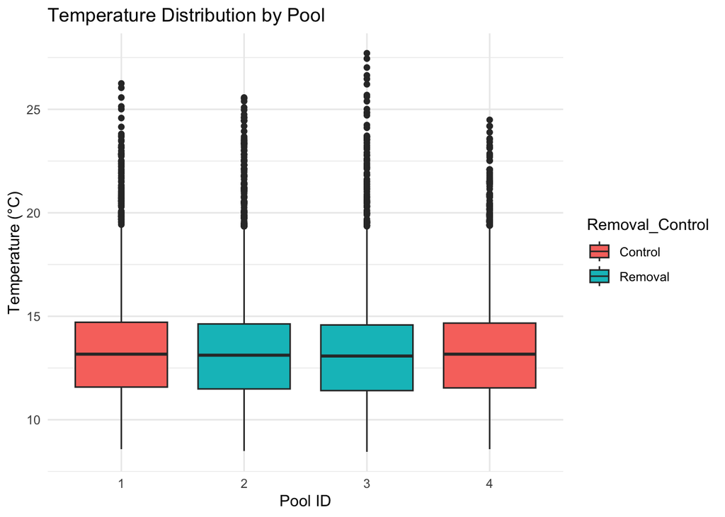

Temperature by Pool

```r
#load and clean all data for plotting
all_data <- map_dfr(files, read_csv, show_col_types = FALSE) %>%
  mutate(
    Intensity.lux = parse_number(as.character(Intensity.lux)),
    Temp.C = as.numeric(as.character(Temp.C))
  )

#create the figure
ggplot(all_data, aes(x = factor(PoolID), y = Temp.C, fill = Removal_Control)) +
  geom_boxplot() +
  labs(x = "Pool ID", y = "Temperature (°C)", title = "Temperature Distribution by Pool") +
  theme_minimal()
```